RED WINE ANALYSIS by Trang Nguyen

========================================================

# Univariate Plots Section

In this section, I would explore the distributions of all variables.

Next, I’m going to investigate the distribution of each variable.

#### Fixed Acidity plot

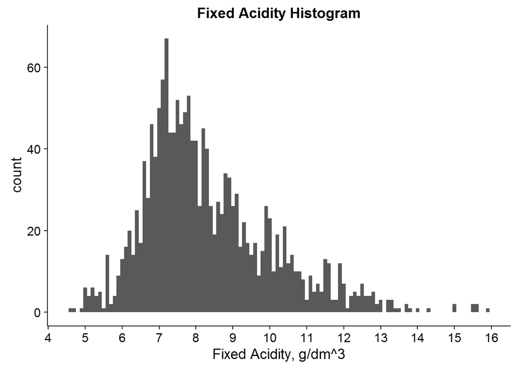

```
##    Min. 1st Qu.  Median    Mean 3rd Qu.    Max.
##    4.60    7.10    7.90    8.32    9.20   15.90
```

#### Volatile Acidity plot

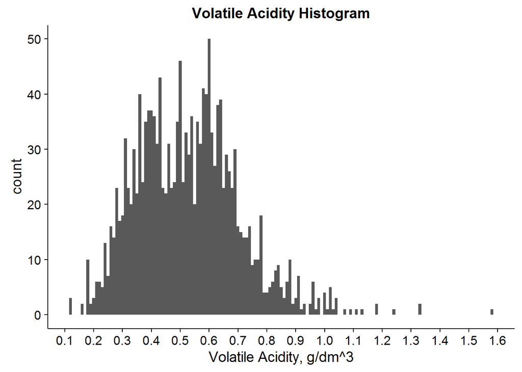

```
##    Min. 1st Qu.  Median    Mean 3rd Qu.    Max.
##  0.1200  0.3900  0.5200  0.5278  0.6400  1.5800
```

#### Citric Acid plot

There is quite a significant number of wines with 0 amount of citric acid: 132 wines (~8% of the samples). There are also some peaks (more than 50 counts) at ranges (0.02,0.03], (0.2,0.21], (0.23, 0.24], (0.48,0.49].

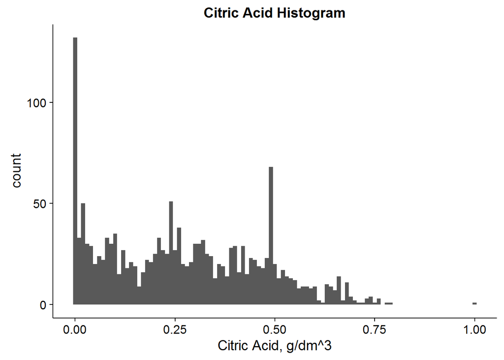

```
## cut_citric.acid
##   (-0.01,0]    (0,0.01] (0.01,0.02] (0.02,0.03] (0.03,0.04] (0.04,0.05]
##         132          33           0          80          29           0
## (0.05,0.06] (0.06,0.07] (0.07,0.08] (0.08,0.09]  (0.09,0.1]  (0.1,0.11]
##          44          22          33          30          35          15
## (0.11,0.12] (0.12,0.13] (0.13,0.14] (0.14,0.15] (0.15,0.16] (0.16,0.17]
##          27          18           0          40           9           0
## (0.17,0.18] (0.18,0.19]  (0.19,0.2]  (0.2,0.21] (0.21,0.22] (0.22,0.23]
##          38          21           0          58          27           0
## (0.23,0.24] (0.24,0.25] (0.25,0.26] (0.26,0.27] (0.27,0.28] (0.28,0.29]
##          76          27          38          20           0          40
##  (0.29,0.3]  (0.3,0.31] (0.31,0.32] (0.32,0.33] (0.33,0.34] (0.34,0.35]
##          30          30          32          25          24          13
## (0.35,0.36] (0.36,0.37] (0.37,0.38] (0.38,0.39]  (0.39,0.4]  (0.4,0.41]
##          20          19          14          28          29          16
## (0.41,0.42] (0.42,0.43] (0.43,0.44] (0.44,0.45] (0.45,0.46] (0.46,0.47]
##          29          15          23          22          19          18
## (0.47,0.48] (0.48,0.49]  (0.49,0.5]  (0.5,0.51] (0.51,0.52] (0.52,0.53]
##          23          68          20          13          17          14
## (0.53,0.54] (0.54,0.55] (0.55,0.56] (0.56,0.57] (0.57,0.58] (0.58,0.59]
##          13          12           8           9           9           8
##  (0.59,0.6]  (0.6,0.61] (0.61,0.62] (0.62,0.63] (0.63,0.64] (0.64,0.65]
##           9           2           1          10           9           7
## (0.65,0.66] (0.66,0.67] (0.67,0.68] (0.68,0.69]  (0.69,0.7]  (0.7,0.71]
##          14           2          11           4           2           1
## (0.71,0.72] (0.72,0.73] (0.73,0.74] (0.74,0.75] (0.75,0.76] (0.76,0.77]
##           1           3           4           1           3           0
## (0.77,0.78] (0.78,0.79]  (0.79,0.8]  (0.8,0.81] (0.81,0.82] (0.82,0.83]
##           1           1           0           0           0           0
## (0.83,0.84] (0.84,0.85] (0.85,0.86] (0.86,0.87] (0.87,0.88] (0.88,0.89]
##           0           0           0           0           0           0
##  (0.89,0.9]  (0.9,0.91] (0.91,0.92] (0.92,0.93] (0.93,0.94] (0.94,0.95]
##           0           0           0           0           0           0
## (0.95,0.96] (0.96,0.97] (0.97,0.98] (0.98,0.99]    (0.99,1]
##           0           0           0           0           1
```

```
##    Min. 1st Qu.  Median    Mean 3rd Qu.    Max.
##   0.000   0.090   0.260   0.271   0.420   1.000
```

#### Residual Sugar plots

Since the original histogram for residual sugar is right skewed, I log-transformed it.

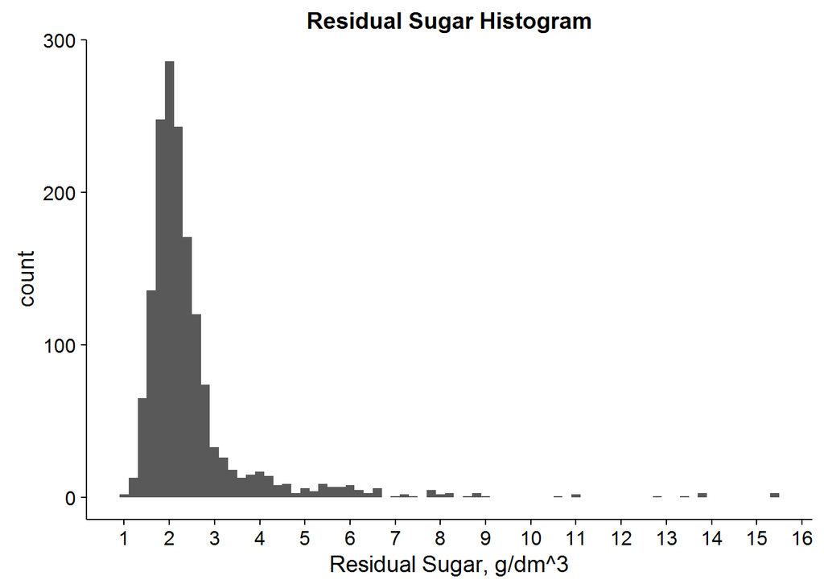

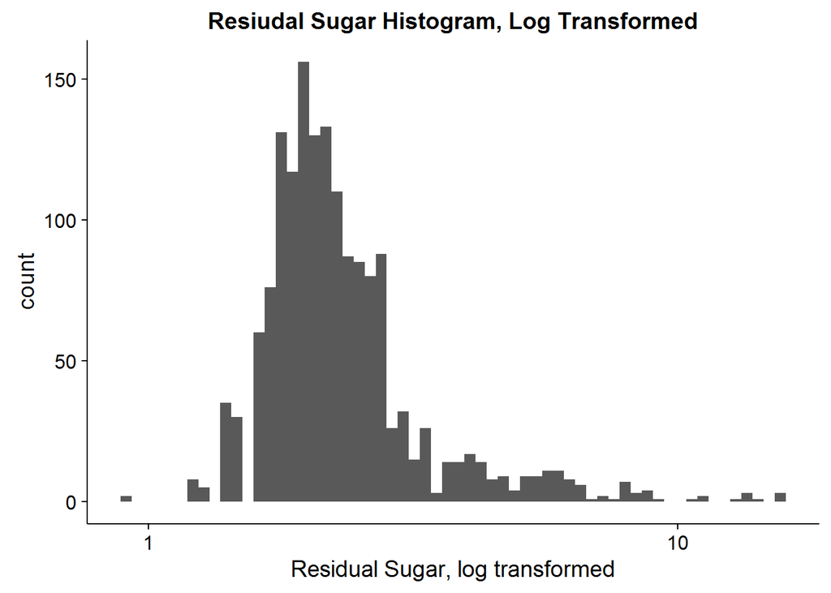

```
##    Min. 1st Qu.  Median    Mean 3rd Qu.    Max.
##   0.900   1.900   2.200   2.539   2.600  15.500
```

#### Chlorides plot

There are a big number of ouliers for chlorides. After limit to 3% and 97% quantiles for this feature, I log transformed to get a more normalized distribution.

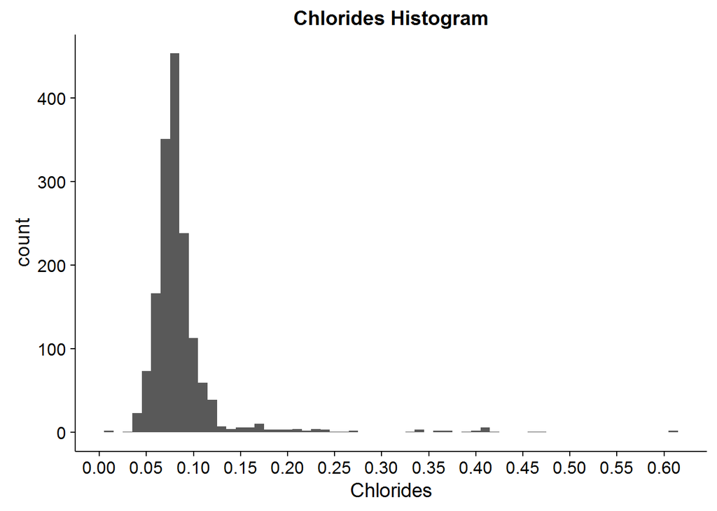

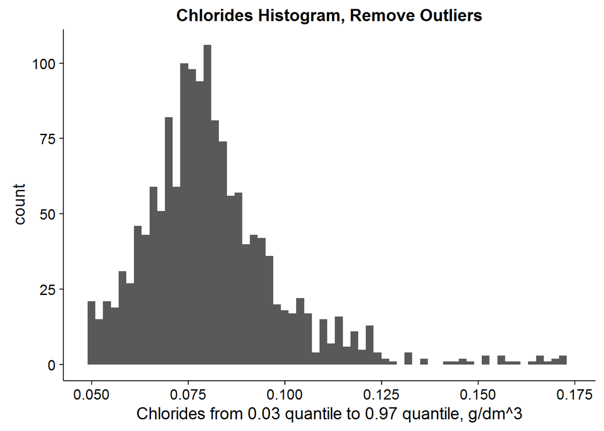

[figure not shown]

```
##    Min. 1st Qu.  Median    Mean 3rd Qu.    Max.
## 0.01200 0.07000 0.07900 0.08747 0.09000 0.61100
```

#### Free Sulfur Dioxide plot

Based on the table, we can see that there is a big number of wines which have free sulfur dioxide of 5 and 6 mg/dm^3. 104 wines have free sulfur dioxide of 5 and 138 wines of 6. The histogram for free sulfur dioxide is right skewed so I log transformed it.

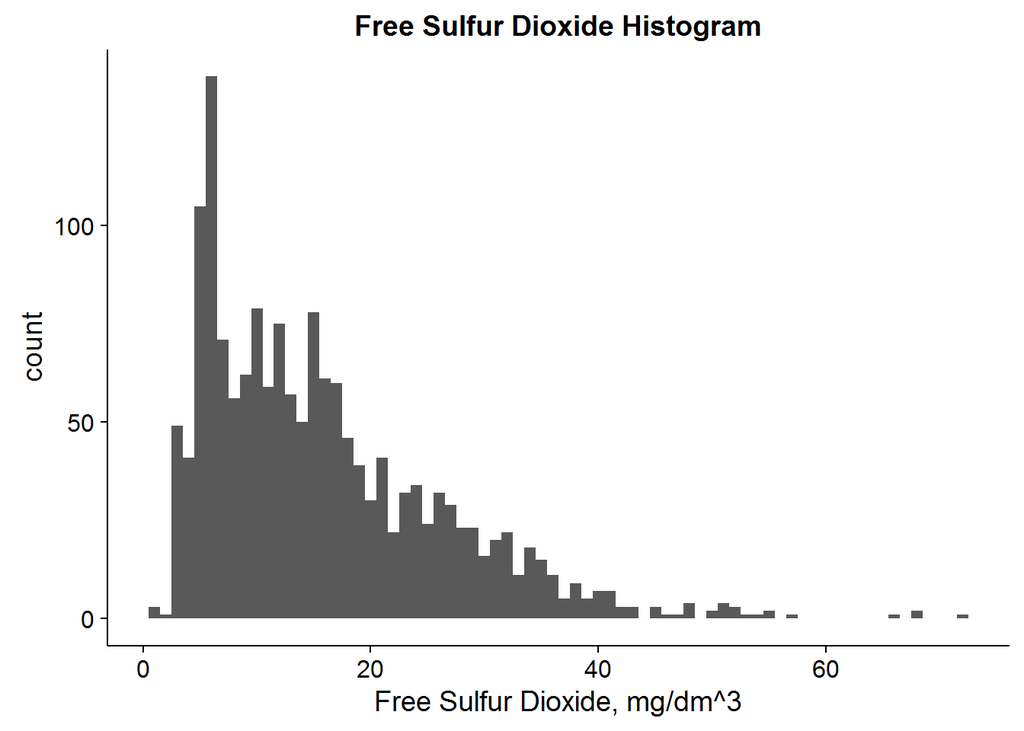

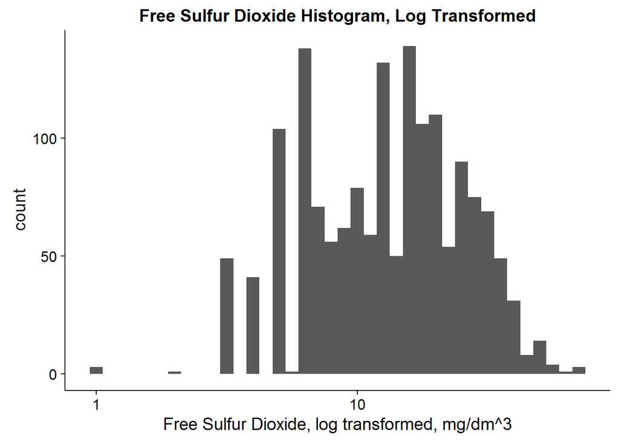

```
##
##    1    2    3    4    5  5.5    6    7    8    9   10   11   12   13   14
##    3    1   49   41  104    1  138   71   56   62   79   59   75   57   50
##   15   16   17   18   19   20   21   22   23   24   25   26   27   28   29
##   78   61   60   46   39   30   41   22   32   34   24   32   29   23   23
##   30   31   32   33   34   35   36   37 37.5   38   39   40 40.5   41   42
##   16   20   22   11   18   15   11    3    2    9    5    6    1    7    3
##   43   45   46   47   48   50   51   52   53   54   55   57   66   68   72
##    3    3    1    1    4    2    4    3    1    1    2    1    1    2    1
```

```
##    Min. 1st Qu.  Median    Mean 3rd Qu.    Max.
##    1.00    7.00   14.00   15.87   21.00   72.00
```

#### Total Sulfur Dioxide plot

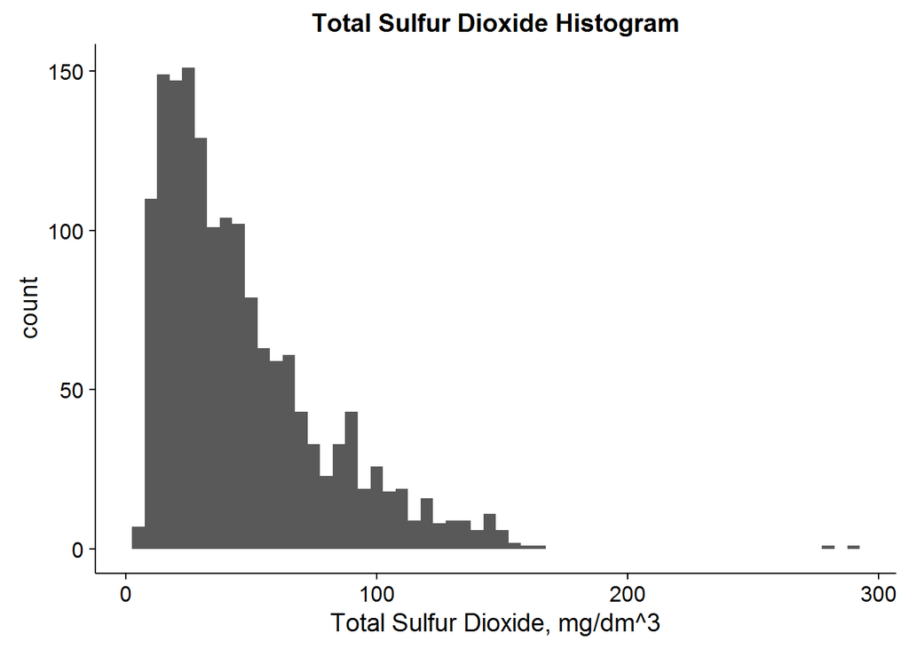

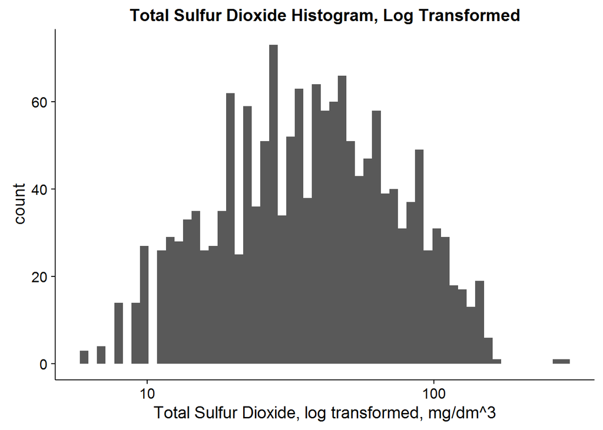

```
## cut_total.sulfur.dioxide
##     (0,5]    (5,10]   (10,15]   (15,20]   (20,25]   (25,30]   (30,35]
##         0        62       151       150       147       131       115
##   (35,40]   (40,45]   (45,50]   (50,55]   (55,60]   (60,65]   (65,70]
##       102       101        94        73        57        58        47
##   (70,75]   (75,80]   (80,85]   (85,90]   (90,95]  (95,100] (100,105]
##        37        26        27        44        29        21        22
## (105,110] (110,115] (115,120] (120,125] (125,130] (130,135] (135,140]
##        19        14        10        12         9        10         4
## (140,145] (145,150] (150,155] (155,160] (160,165] (165,170] (170,175]
##        12         6         5         1         1         0         0
## (175,180] (180,185] (185,190] (190,195] (195,200] (200,205] (205,210]
##         0         0         0         0         0         0         0
## (210,215] (215,220] (220,225] (225,230] (230,235] (235,240] (240,245]
##         0         0         0         0         0         0         0
## (245,250] (250,255] (255,260] (260,265] (265,270] (270,275] (275,280]
##         0         0         0         0         0         0         1
## (280,285] (285,290] (290,295] (295,300]
##         0         1         0         0
```

```
##    Min. 1st Qu.  Median    Mean 3rd Qu.    Max.
##    6.00   22.00   38.00   46.47   62.00  289.00
```

#### Density plot

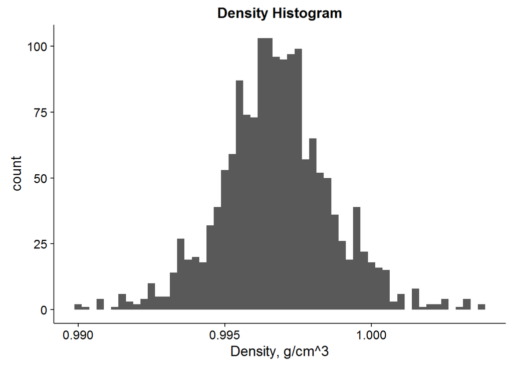

```
##    Min. 1st Qu.  Median    Mean 3rd Qu.    Max.
##  0.9901  0.9956  0.9968  0.9967  0.9978  1.0040
```

#### pH plot

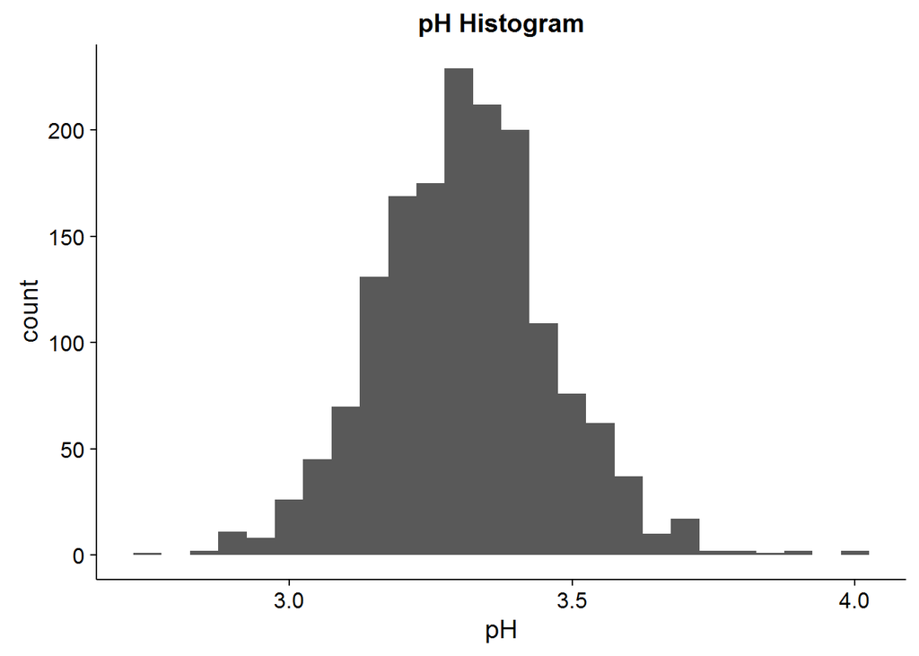

```
##    Min. 1st Qu.  Median    Mean 3rd Qu.    Max.
##   2.740   3.210   3.310   3.311   3.400   4.010
```

#### Sulphates plot

I log transformed sulphates to get a more normalized distribution.

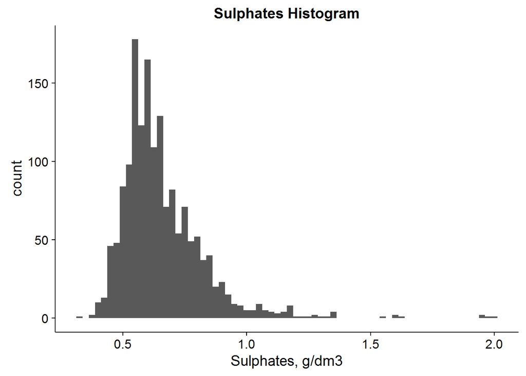

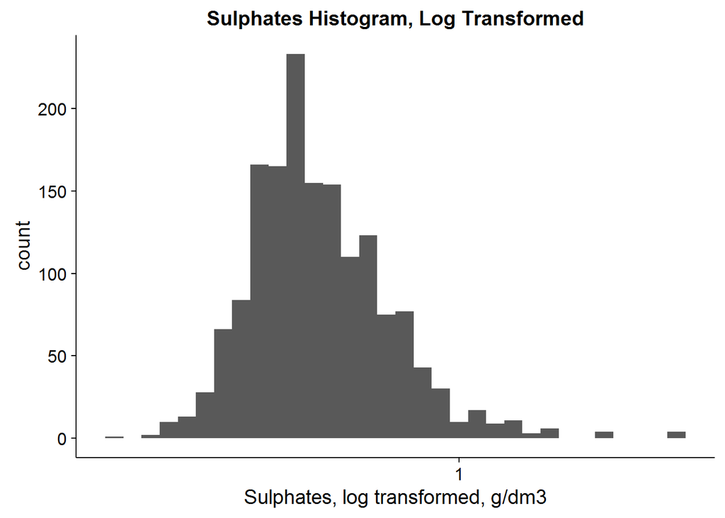

```
##    Min. 1st Qu.  Median    Mean 3rd Qu.    Max.
##  0.3300  0.5500  0.6200  0.6581  0.7300  2.0000
```

#### Alcohol plot

Based on the table, we can see that there are more wines which have alcohol percentage of from 9.2 to 10 (686 wines ~ 43% of total samples).

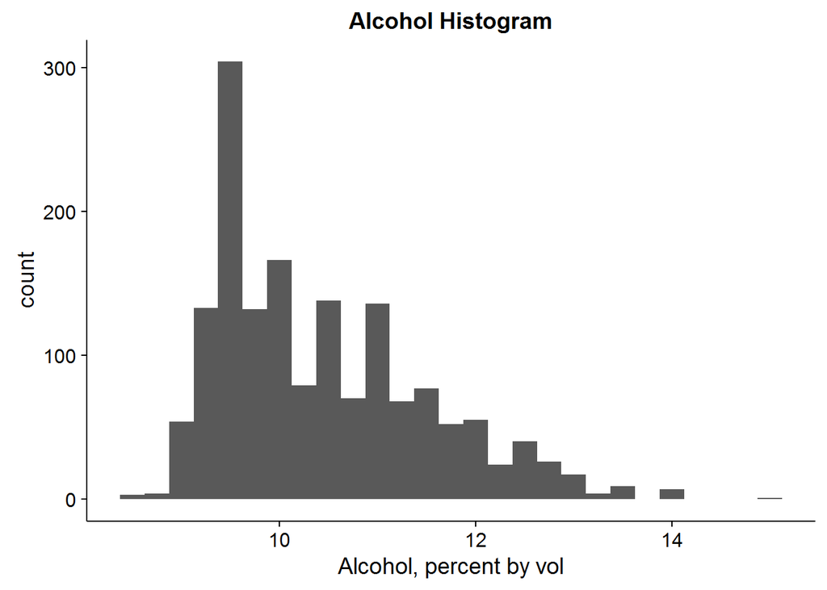

```
##    Min. 1st Qu.  Median    Mean 3rd Qu.    Max.
##    8.40    9.50   10.20   10.42   11.10   14.90
```

```
##
##              8.4              8.5              8.7              8.8
##                2                1                2                2
##                9             9.05              9.1              9.2
##               30                1               23               72
## 9.23333333333333             9.25              9.3              9.4
##                1                1               59              103
##              9.5             9.55 9.56666666666667              9.6
##              139                2                1               59
##              9.7              9.8              9.9             9.95
##               54               78               49                1
##               10 10.0333333333333             10.1             10.2
##               67                2               47               46
##             10.3             10.4             10.5            10.55
##               33               41               67                2
##             10.6             10.7            10.75             10.8
##               28               27                1               42
##             10.9               11 11.0666666666667             11.1
##               49               59                1               27
##             11.2             11.3             11.4             11.5
##               36               32               32               30
##             11.6             11.7             11.8             11.9
##               15               23               29               20
##            11.95               12             12.1             12.2
##                1               21               13               12
##             12.3             12.4             12.5             12.6
##               12               13               21                6
##             12.7             12.8             12.9               13
##                9               17                9                6
##             13.1             13.2             13.3             13.4
##                2                1                3                3
##             13.5 13.5666666666667             13.6               14
##                1                1                4                7
##             14.9
##                1
```

```
##
##  (8,10] (10,12] (12,14] (14,16]
##     747     711     140       1
```

#### Quality plot

The majority of the wines have quality 5 and 6 (82% of all samples). 13.6% of all samples have quality 7 and 8.

```
##
##   3   4   5   6   7   8
##  10  53 681 638 199  18
```

# Univariate Analysis

#### What is the structure of your dataset?

This dataset consists of rating and 11 attributes of 1599 types of wine. The attributes are:

1. fixed.acidity
2. volatile.acidity
3. citric.acid
4. residual.sugar
5. chlorides
6. free.sulfur.dioxide
7. total.sulfur.dioxide
8. density
9. pH
10. sulphates
11. alcohol

Quality has values from 3 to 8 where wine types having quality 5 and 6 accounting for more than 80% of the total.

#### What is/are the main feature(s) of interest in your dataset?

With this analysis, I would like to find which attributes are most likely to effect the quality of the wine. I also did some reading online to have a background for this study. The main features of interest that I think I will focus on more are alcohol, citric acid and residual sugar.

#### What other features in the dataset do you think will help support your investigation into your feature(s) of interest?

I think the combination of fixed and volatile acidity as well as density can support the investigation also.

#### Did you create any new variables from existing variables in the dataset?

I created brackets for alcohol and citric acid to help with the analysis later. For alcohol, I have 4 brackets: 8-10%, 10-12%, 12-14% and 14-16%. For citric acid, I have 6 brackets: 0-0.14, 0.14-0.29, 0.29-0.44, 0.44-0.59, 0.59-0.74 and 0.74-0.89 g/dm^3.

#### Of the features you investigated, were there any unusual distributions? Did you perform any operations on the data to tidy, adjust, or change the form of the data? If so, why did you do this?

For some of the positive skewed attributes, I had to transform them into log histogram.

# Bivariate Plots Section

Firstly, I created ggcorr plot to get the overall relationships between the variables in the dataset.

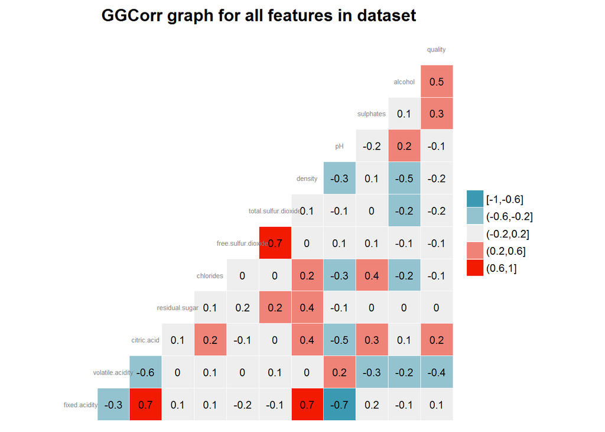

We can see some relationships between the variables as below:

Strong positive correlation (>0.6):

- Fixed Acidity and Citric Acid
- Fixed Acidity and Density
- Free Sulfure Dioxide and Total Sulfur Dioxide

Strong negative correlation (<-0.6):

- Fixed Acidity and pH

Medium positive correlation (>0.2, <0.6):

- Volatile Acidity and pH
- Citric Acid and Chlorides
- Citric Acid and Density
- Citric Acid and Sulphates
- Citric Acid and Quality
- Residual Sugar and Total Sulfur Dioxide
- Residual Sugar and Density
- Chlorides and Density
- Chlorides and Sulphates
- pH and Alcohol
- Sulphates and Quality
- Alcohol and Quality

- Fixed Acidity and Volatile Acidity
- VOlatile Acidity and Citric Acid
- VOlatile Acidity and Sulphates
- VOlatile Acidity and Alcohol
- Volatile Acidity and Quality
- Citric Acid and pH
- Chlorides and pH
- Chlorides and Alochol
- Total Sulfur Dioxide and Alcohol
- Density and Alcohol
- Density and pH

#### Alcohol vs Quality

As we can see from the box plot, higher quality wines have higher percentage of alcohol. However, there are not many wines that have very high percentage of alcohol; so it does not guarantee that higher percentage of alcohol will make the wine taste good.

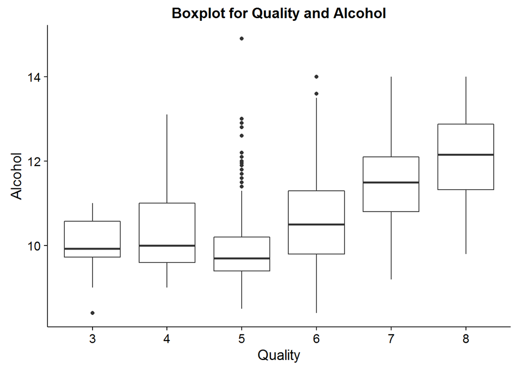

```
##
##  Pearson's product-moment correlation
##
## data:  wine$quality and wine$alcohol
## t = 21.639, df = 1597, p-value < 2.2e-16
## alternative hypothesis: true correlation is not equal to 0
## 95 percent confidence interval:
##  0.4373540 0.5132081
## sample estimates:
##       cor
## 0.4761663
```

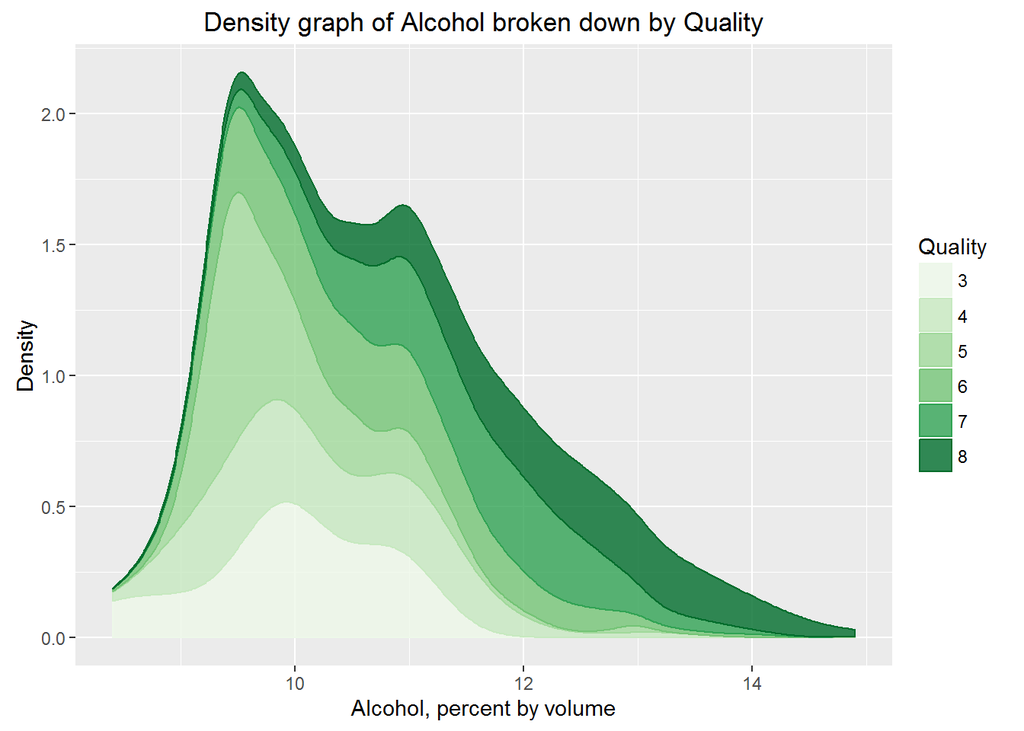

```
## $`3`
##    Min. 1st Qu.  Median    Mean 3rd Qu.    Max.
##   8.400   9.725   9.925   9.955  10.580  11.000
##
## $`4`
##    Min. 1st Qu.  Median    Mean 3rd Qu.    Max.
##    9.00    9.60   10.00   10.27   11.00   13.10
##
## $`5`
##    Min. 1st Qu.  Median    Mean 3rd Qu.    Max.
##     8.5     9.4     9.7     9.9    10.2    14.9
##
## $`6`
##    Min. 1st Qu.  Median    Mean 3rd Qu.    Max.
##    8.40    9.80   10.50   10.63   11.30   14.00
##
## $`7`
##    Min. 1st Qu.  Median    Mean 3rd Qu.    Max.
##    9.20   10.80   11.50   11.47   12.10   14.00
##
## $`8`
##    Min. 1st Qu.  Median    Mean 3rd Qu.    Max.
##    9.80   11.32   12.15   12.09   12.88   14.00
```

#### Volatile Acidity vs Quality

As we can see from the charts, wines with lower amount of volatile acidity seem to have higher quanlity points.

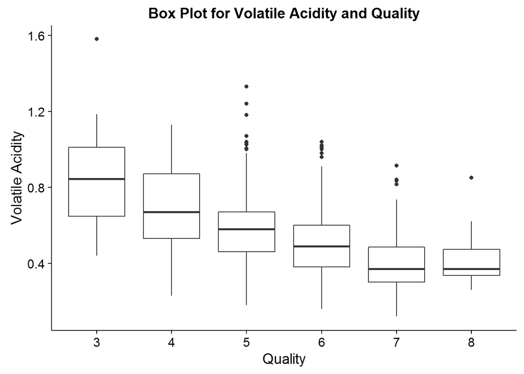

```
##
##  Pearson's product-moment correlation
##
## data:  wine$quality and wine$volatile.acidity
## t = -16.954, df = 1597, p-value < 2.2e-16
## alternative hypothesis: true correlation is not equal to 0
## 95 percent confidence interval:
##  -0.4313210 -0.3482032
## sample estimates:
##        cor
## -0.3905578
```

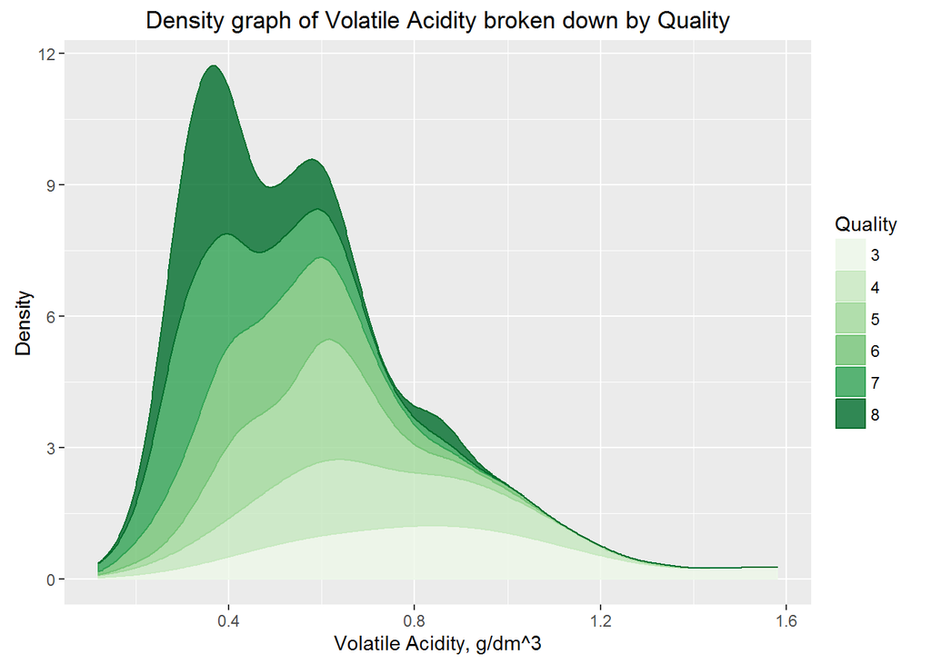

```
## $`3`
##    Min. 1st Qu.  Median    Mean 3rd Qu.    Max.
##  0.4400  0.6475  0.8450  0.8845  1.0100  1.5800
##
## $`4`
##    Min. 1st Qu.  Median    Mean 3rd Qu.    Max.
##   0.230   0.530   0.670   0.694   0.870   1.130
##
## $`5`
##    Min. 1st Qu.  Median    Mean 3rd Qu.    Max.
##   0.180   0.460   0.580   0.577   0.670   1.330
##
## $`6`
##    Min. 1st Qu.  Median    Mean 3rd Qu.    Max.
##  0.1600  0.3800  0.4900  0.4975  0.6000  1.0400
##
## $`7`
##    Min. 1st Qu.  Median    Mean 3rd Qu.    Max.
##  0.1200  0.3000  0.3700  0.4039  0.4850  0.9150
##
## $`8`
##    Min. 1st Qu.  Median    Mean 3rd Qu.    Max.
##  0.2600  0.3350  0.3700  0.4233  0.4725  0.8500
```

Below are scatter plots for other pairs of variables with strong correlations that we found.

#### Fixed Acidity vs Citric Acid

Fixed Acidity and Citric Acid has strong positive correlation (0.67 from Pearson’s test) as in the graph.

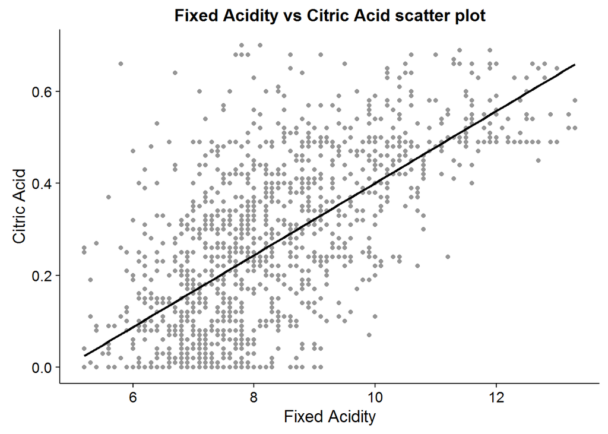

#### Fixed Acidity vs Density

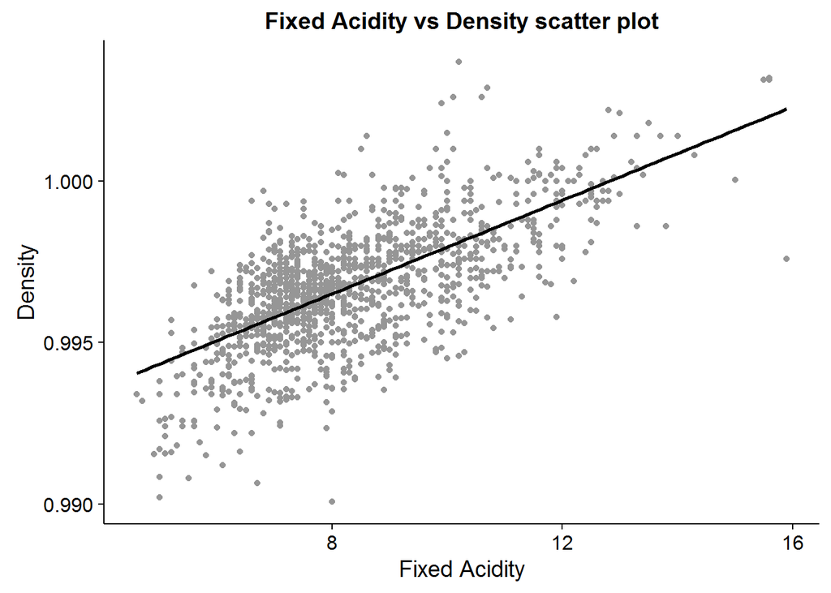

#### Fixed Acidity vs pH

Fixed Acidity and pH has strong negative correlation (-0.68 from Pearson’s test)

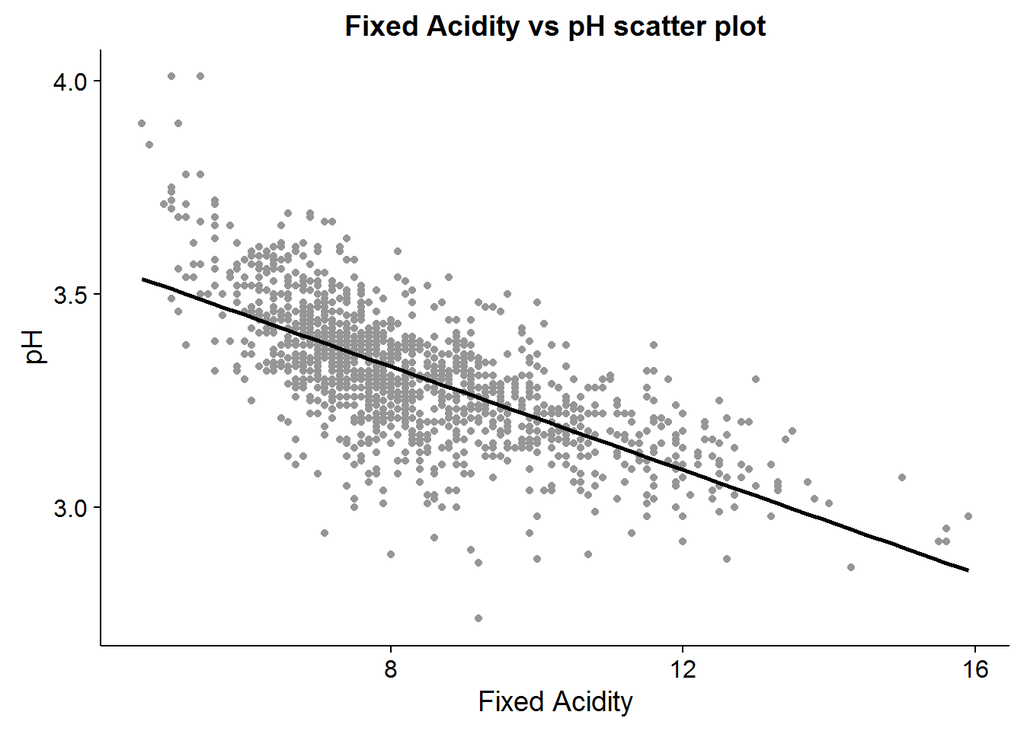

#### Free Sulfur Dioxide vs Total Sulfur Dioxide

Free Sulfur Dioxide and Total Sulfur Dioxide unsurprisingly has high positive correlation (0.67 from Pearons’s test).

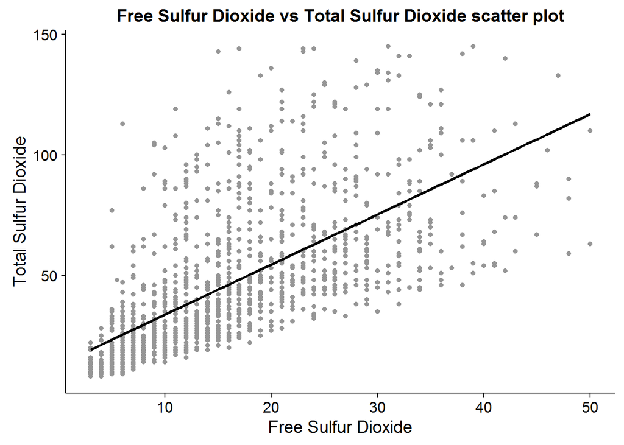

#### Citric Acid vs Volatile Acidity

Citric Acid and Volatile Acidity are 0.55 correlated (from Pearson’s test).

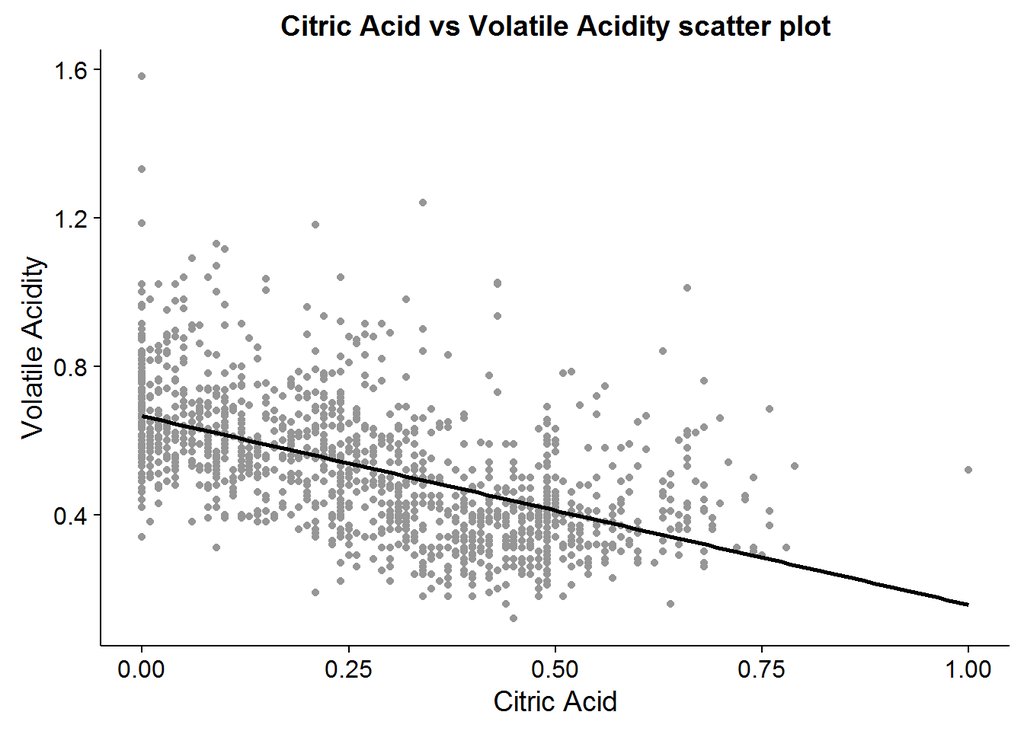

#### Citric Acid vs pH

Citric Acid and pH has 0.54 Pearson’s correlation.

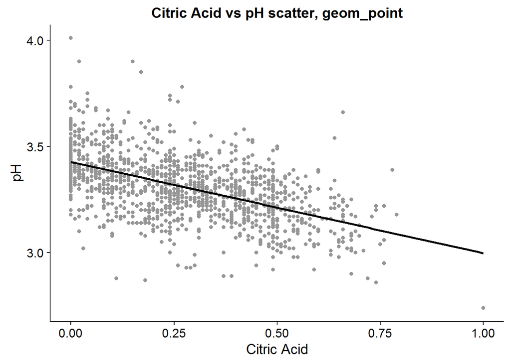

# Bivariate Analysis

#### Talk about some of the relationships you observed in this part of the investigation. How did the feature(s) of interest vary with other features in the dataset?

The investigations about relationships between features were based on Pearson correlation.

Citric acid has: - large positive correlation with fixed acidity (0.67), - large negative correlation with volatile acidity (-0.55), - large negative correlation with pH (-0.54), - medium postivie correlation with density (0.36)

Residual sugar has: - medium positive correlation with density (0.36) - Alcohol has: - medium positive correlation with quality (0.48) - medium negative correlation with density (-0.5).

#### Did you observe any interesting relationships between the other features (not the main feature(s) of interest)?

Fixed acidity has: - large positive correlation with density (0.67) - large negative correlation with pH (-0.68)

Volatile acidity has medium negative correlation with quality (-0.39)

Chlorides has medium positive correlation with sulphates (0.37)

Free sulfur has strong postivie correlation with total sulfur dioxide (0.67)

Density has - medium negative correlation with ph - medium negative correlation alcohol

# Multivariate Plots Section

#### Citric Acid, Fixed Acidity and Quality

This is a scatter plot of fixed acidity and citric acid with the colors of the points are by quality points.It seems like higher quality wines have higher fixed acidity and higher citric acid.

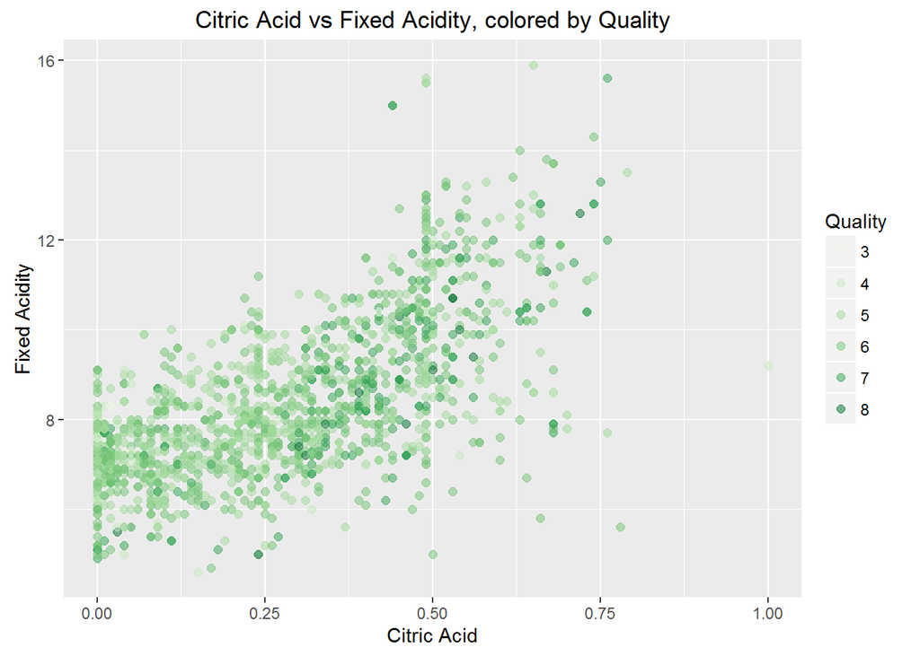

#### Citric Acid, Volatile Acidity and Quality

I have another scatter plot of volatile acidity and citric acid with the colors of the points are by quality points. In this plot, the higher quality wines seem to concentrate where citric acid is high and volatile acidity is low.

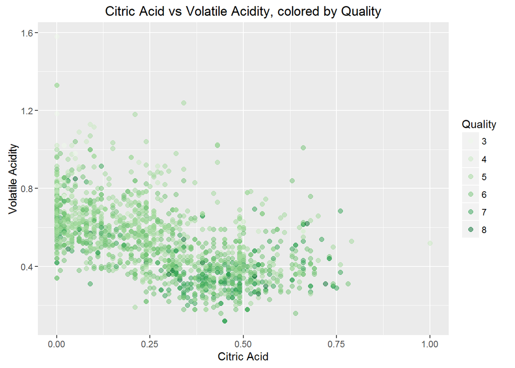

#### Citric Acid, pH and Quality

In this plot, higher quality wines have higher citric acid and lower pH.

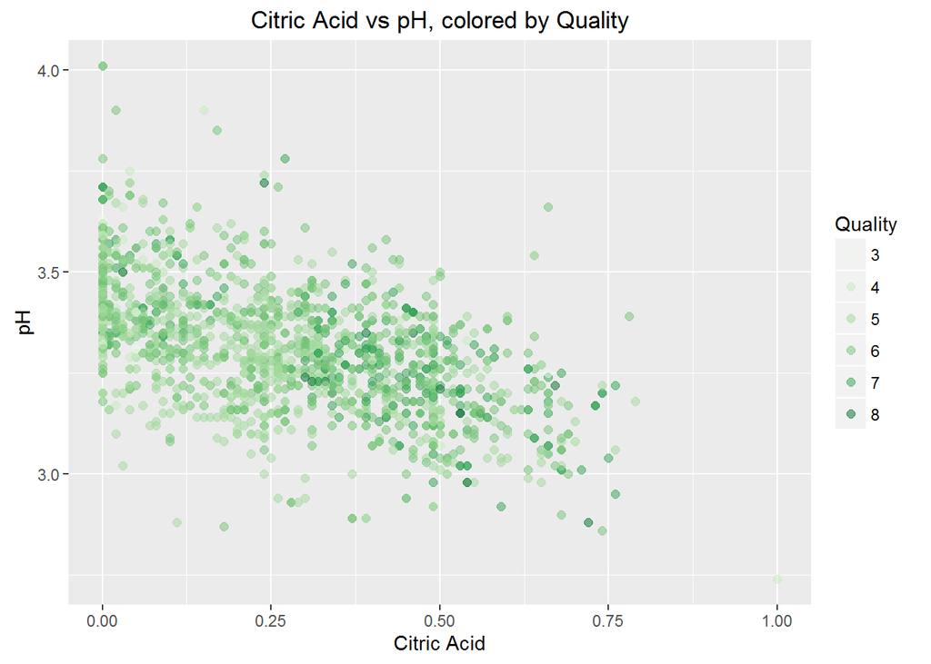

#### Citric Acid, Density and Quality

This plot doesn’t seem to show any trend to conclude anything about the relationship between these three variables.

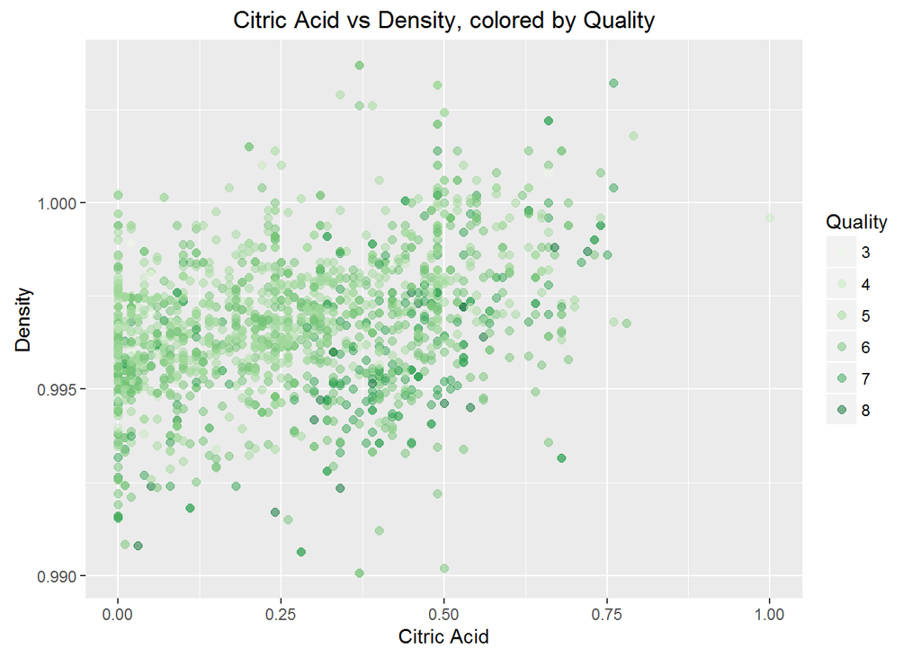